# Social Media Analysis

Ashita Shetty

##### Loading the Packages

```r
library(readr)
library(corpcor)
library(Hotelling)
library(lattice)
library(ggplot2)
library(ggridges)
library(ggvis)
library(ggthemes)
library(cowplot)
library(gapminder)
library(gganimate)
library(dplyr)
library(tidyverse)
library(grid)
library(gridExtra)
library(RColorBrewer)

library(cluster)
library(readr)
library(factoextra)
library(FactoMineR)
library(magrittr)
library(NbClust)
library(psych)
options(scipen=999)

library(caret)
library(e1071)
library(pROC)
library(MASS)
library(memisc)
library(ROCR)
library(dplyr)
library(klaR)
```

##### Dataset Loading

```r
social_media <- read.csv("C:\\Users\\Dell\\Desktop\\RBS\\Semester II\\Multivariate Analysis\\Assignment\\Social_Media\\MVA_Social_Media_Cleaned.csv", row.names = 1)

social_media_num <- social_media[, c("Instagram_Hours", "LinkedIn_Hours",   "Snapchat_Hours", "Twitter_Hours",  "Whatsapp_Wechat_hours", "Reddit_hours",    "Youtube_hours",    "OTT_hours")]
```

```r
str(social_media)
```

```
## 'data.frame':    21 obs. of  16 variables:
##  $ Instagram_Hours                              : num  12 7.73 3.77 5.38 0 2.33 5.37 7 8.65 0.17 ...
##  $ LinkedIn_Hours                               : num  4 5.2 7 5.32 0.58 7 4 4 10 0 ...
##  $ Snapchat_Hours                               : num  1 3.68 0.53 1.3 0 0.47 0 3 3.83 0 ...
##  $ Twitter_Hours                                : num  5 0 0 0 0.67 0 0 0 0 0 ...
##  $ Whatsapp_Wechat_hours                        : num  1 4.18 9.83 5.3 3 12 6 10 6.15 1 ...
##  $ Reddit_hours                                 : num  2.5 0 0 0 1 0 0 0 0 0 ...
##  $ Youtube_hours                                : num  2.5 4.25 1.85 2 3.5 7 3 2 4 3 ...
##  $ OTT_hours                                    : num  14.5 0 2 2 2 3 0 3 3 0 ...
##  $ Application.type.Social.media..OTT..Learning.: chr  "OTT" "Social Media" "Social Media" "Social Media" ...
##  $ Interview_calls                              : num  0 0 0 2 0 0 0 0 1 0 ...
##  $ Networking                                   : int  0 1 0 0 2 0 2 0 0 0 ...
##  $ Items_learned                                : num  3 3 4 4 4 4 3 2 6 2 ...
##  $ Mood_Productivity                            : chr  "Yes" "Yes" "Yes" "Yes" ...
##  $ Tired_Morning                                : chr  "No" "No" "No" "No" ...
##  $ Trouble_Sleeping                             : chr  "No" "Yes" "No" "No" ...
##  $ Entire_Week_Feeling                          : int  3 3 4 4 3 5 4 4 3 2 ...
```

##### Converting ‘chr’ columns into factors

```r
social_media$Trouble_Sleeping_num <- ifelse(test=social_media$Trouble_Sleeping == 'Yes', 1, 0)
social_media$Tired_Morning_num <- ifelse(test=social_media$Tired_Morning == 'Yes', 1, 0)
social_media$Mood_Productivity_num <- ifelse(test=social_media$Mood_Productivity == 'Yes', 1, 0)
```

```r
social_media$Trouble_Sleeping <- ifelse(test=social_media$Trouble_Sleeping == 'Yes', yes="Troubled", no="Not Troubled")
social_media$Trouble_Sleeping <- as.factor(social_media$Trouble_Sleeping)

social_media$Tired_Morning <- ifelse(test=social_media$Tired_Morning == 'Yes', yes="Tired", no="Not Tired")
social_media$Tired_Morning <- as.factor(social_media$Tired_Morning)

social_media$Mood_Productivity <- ifelse(test=social_media$Mood_Productivity == 'Yes', yes="Productive", no="Not Productive")
social_media$Mood_Productivity <- as.factor(social_media$Mood_Productivity)

#For Cluster Analysis
matstd_socialmedia <- scale(social_media_num)
```

#### **Exploratory Data Analysis (EDA)**

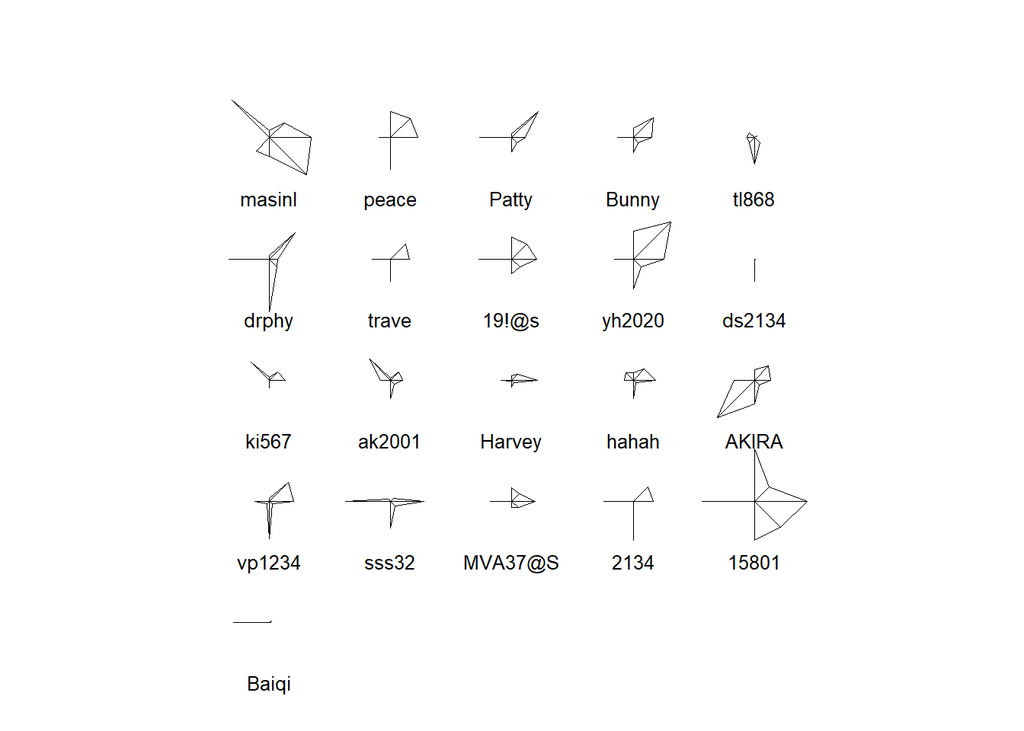

```r
stars(social_media_num)
```

**Inferences:**

- Stars diagram is a great way to observe students with similar application usage. While not everybody has the exact same pattern, similar students can be spotted based on the applications used or average time of use.
- For example, 19!@s, MVA37@S, yh2020, Bunny, 15801 are students that have used similar apps, however the average consumption differed. While MVA37@S is not an extensive social media user, 15801 seems to have been using social media quite a lot.

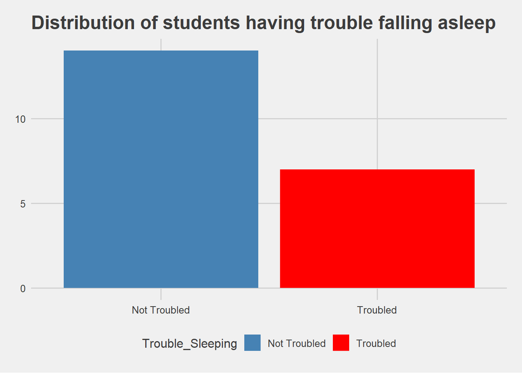

```r
ggplot(social_media, aes(x = Trouble_Sleeping, fill = Trouble_Sleeping)) +
  geom_bar() +
  labs(title = "Distribution of students having trouble falling asleep",
       x = "Status",
       y = "Count") +
  scale_fill_manual(values = c("Not Troubled" = "steelblue", "Troubled" = "red"))+
  theme_fivethirtyeight()
```

**Inferences:**

- An analysis of the number of students have trouble sleeping vs not having any trouble.
- This a great way of understanding an imbalance in the dataset.

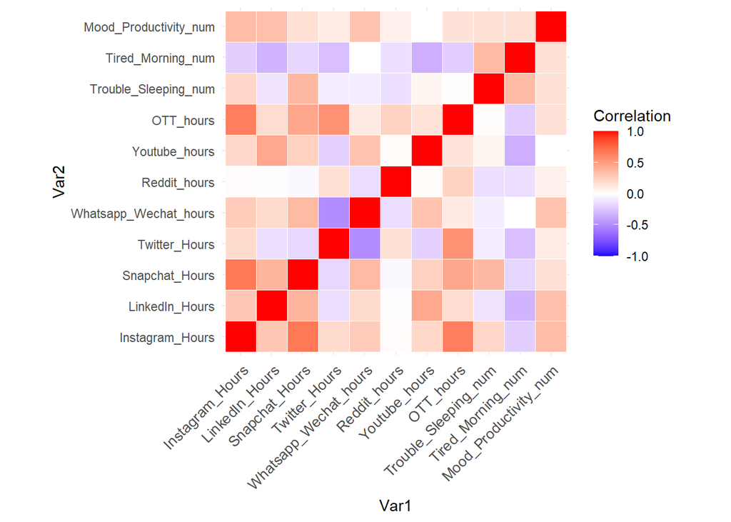

```r
correlation_matrix <- cor(social_media[, c("Instagram_Hours", "LinkedIn_Hours", "Snapchat_Hours", "Twitter_Hours", "Whatsapp_Wechat_hours", "Reddit_hours", "Youtube_hours", "OTT_hours", "Trouble_Sleeping_num", "Tired_Morning_num", "Mood_Productivity_num")])

# Create a heatmap
library(reshape2)
# Convert correlation matrix to long format
correlation_df <- melt(correlation_matrix)

ggplot(correlation_df, aes(Var1, Var2, fill = value)) +
  geom_tile(color = "white") +
  scale_fill_gradient2(low = "blue", high = "red", mid = "white",
                       midpoint = 0, limit = c(-1,1), space = "Lab",
                       name="Correlation") +
  theme_minimal() +
  theme(axis.text.x = element_text(angle = 45, vjust = 1, size = 10, hjust = 1)) +
  coord_fixed()
```

**Inferences:**

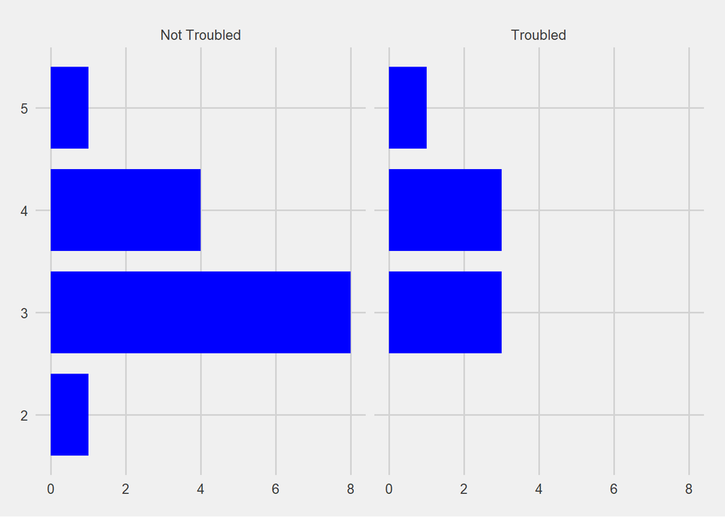

```r
ggplot(social_media, aes(Entire_Week_Feeling)) + facet_grid(.~Trouble_Sleeping) +
  geom_bar(fill="blue", position="stack", width = 0.8) + coord_flip()+ theme_fivethirtyeight()
```

**Inference:**

- An analysis of the average week feeling for every class of sleeping issues.

#### **Let’s carry out Principal Component Analysis to see the different applications and how much variability they bring**

```r
social_media_pca <- prcomp(social_media_num, scale. = TRUE)
summary(social_media_pca)
```

```
## Importance of components:
##                           PC1    PC2    PC3    PC4     PC5     PC6     PC7
## Standard deviation     1.6463 1.3947 1.0176 0.9265 0.80136 0.65798 0.50370
## Proportion of Variance 0.3388 0.2431 0.1294 0.1073 0.08027 0.05412 0.03171
## Cumulative Proportion  0.3388 0.5819 0.7114 0.8187 0.89894 0.95306 0.98477
##                            PC8
## Standard deviation     0.34905
## Proportion of Variance 0.01523
## Cumulative Proportion  1.00000
```

**Inferences:**

- The summary provides a clear understanding of the cumulative variance that the ideal no. of PCs will have.

##### Scree Plot

- To further understand the ideal number of PCs, we can carry out the Scree Plot

```r
(eigen_social_media <- social_media_pca$sdev^2)
```

```
## [1] 2.7102533 1.9451459 1.0354850 0.8584530 0.6421744 0.4329318 0.2537181
## [8] 0.1218383
```

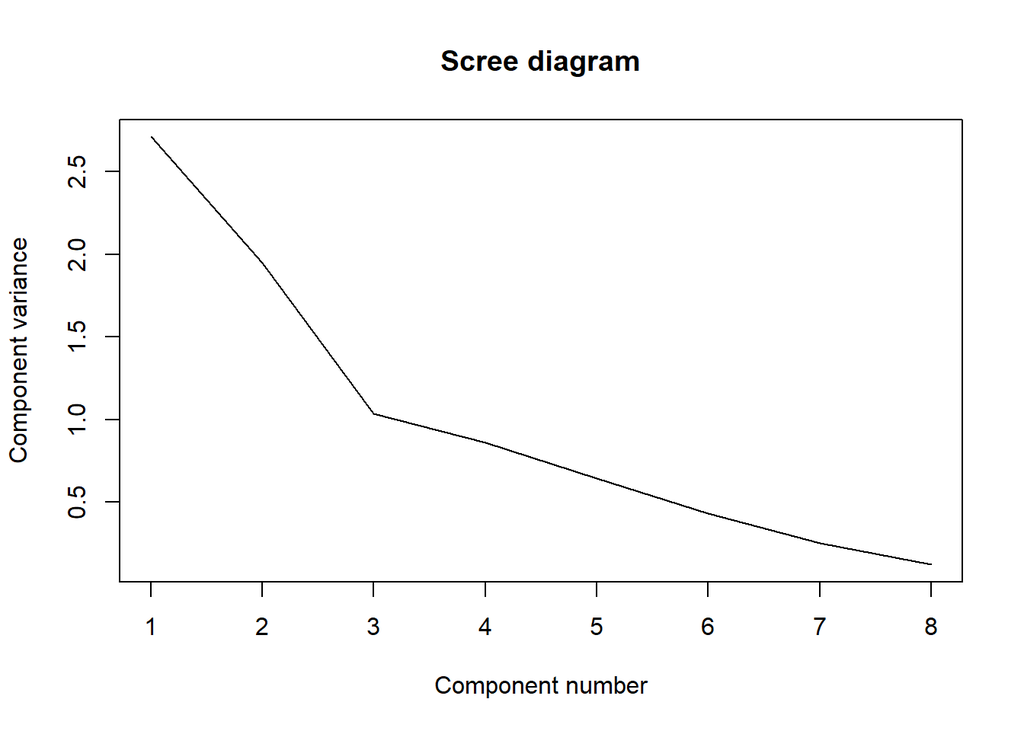

```r
names(eigen_social_media) <- paste("PC",1:8,sep="")

plot(eigen_social_media, xlab = "Component number", ylab = "Component variance", type = "l", main = "Scree diagram")
```

**Inference:**

- As the elbow is formed at the **Component Number 3**, it would be the ideal number of PCs to be used.

##### PCA - BiPlot

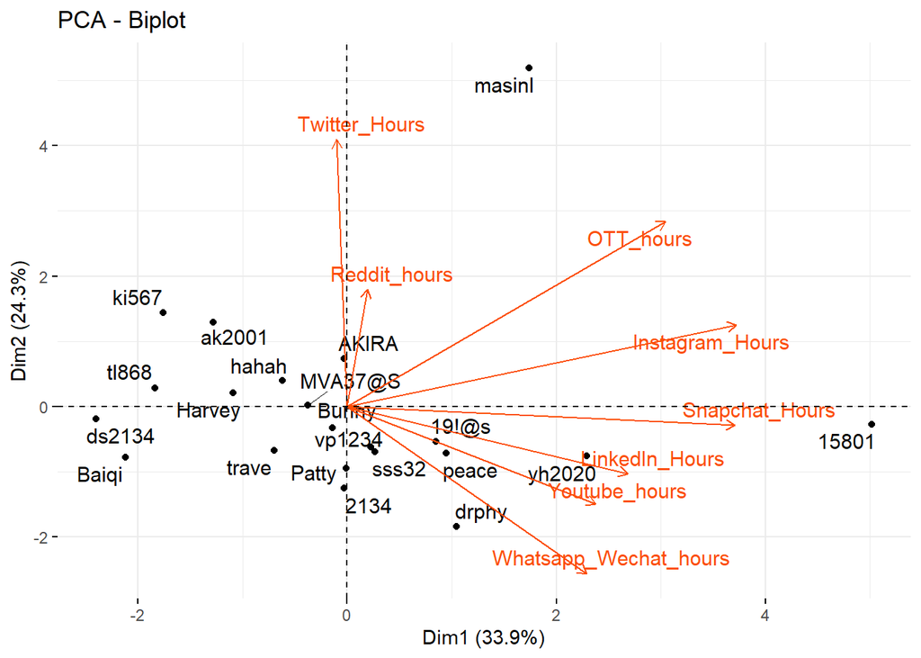

```r
res.pca <- PCA(social_media_num, graph = FALSE)
fviz_pca_biplot(res.pca, repel = TRUE,
                col.var = "#FC4E07", # Variables color
                )
```

**Inferences:**

#### **Cluster Analysis - Grouping of Students based on the similarity of characteristics**

**Identifying ideal number of clusters**

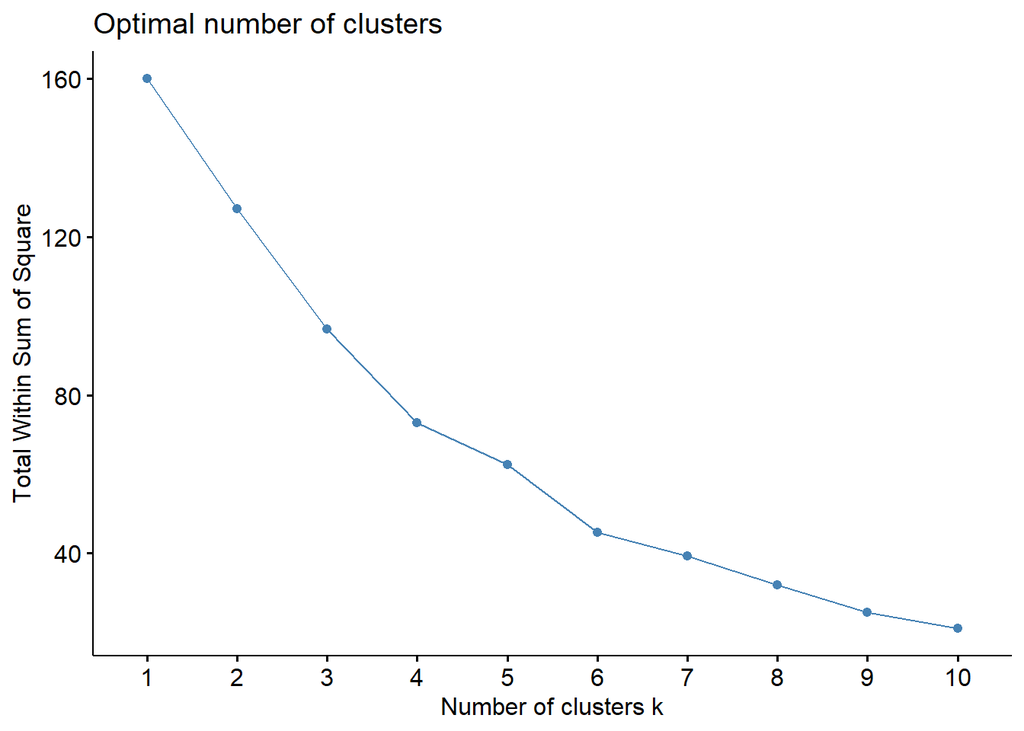

```r
fviz_nbclust(matstd_socialmedia, kmeans, method = "wss")
```

**Inference:**

- It can be observed that **4 may be the ideal number of clusters**

##### Dendogram - To visualize the different possible clusters

```r
dist.sm <- dist(matstd_socialmedia, method = "euclidean")
clussm.nn <- hclust(dist.sm, method = "single")
```

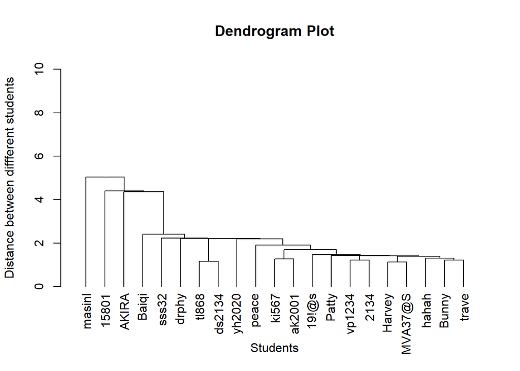

```r
plot(as.dendrogram(clussm.nn),xlab="Students",ylab="Distance between diffferent students",ylim=c(0,10),
     main="Dendrogram Plot")
```

**Inference:**

- A Dendogram is a great way to see the groups that can be formed at the base level on similarity. Shorter height is indicative of higher similarity.
- For instance, “Bunny” and “trave” seem to be grouped together. The two combined can form another cluster with “hahah”.

##### Membership of all clusters

```r
set.seed(123)
kmeans4.sm <- kmeans(matstd_socialmedia, 4, nstart = 25)

kmeans4.sm
```

```
## K-means clustering with 4 clusters of sizes 1, 1, 8, 11
##
## Cluster means:
##   Instagram_Hours LinkedIn_Hours Snapchat_Hours Twitter_Hours
## 1      1.66012348      0.1567109    -0.16267631     3.4244909
## 2      2.47106942      0.1365706     3.31403861    -0.4497850
## 3     -0.61342140     -0.8558441    -0.42122948     0.2204647
## 4      0.07056166      0.5957701     0.01986123    -0.4307658
##   Whatsapp_Wechat_hours Reddit_hours Youtube_hours  OTT_hours
## 1            -1.3459283    1.2381055    -0.2854165  3.4417324
## 2             2.1373721   -0.3334743     1.2670048  2.1642630
## 3            -0.5612755   -0.2438942    -0.7085389 -0.3974180
## 4             0.3362509    0.0951384     0.4260657 -0.2206047
##
## Clustering vector:
##  masinl   peace   Patty   Bunny   tl868   drphy   trave   19!@s  yh2020  ds2134
##       1       4       4       4       3       4       4       4       4       3
##   ki567  ak2001  Harvey   hahah   AKIRA  vp1234   sss32 MVA37@S    2134   15801
##       3       3       3       3       4       4       4       3       4       2
##   Baiqi
##       3
##
## Within cluster sum of squares by cluster:
## [1]  0.00000  0.00000 21.39991 51.68132
##  (between_SS / total_SS =  54.3 %)
##
## Available components:
##
## [1] "cluster"      "centers"      "totss"        "withinss"     "tot.withinss"
## [6] "betweenss"    "size"         "iter"         "ifault"
```

**Inferences:**

- Cluster 1: This cluster tends to have higher values for features like “Reddit_Hours”, “Twitter_Hours”, and “OTT_hours” compared to other clusters. It suggests that data points in this cluster are associated with higher usage of Reddit, Twitter, and OTT platforms.
- Cluster 2: This cluster shows significant values for features like Instagram, WhatsApp/WeChat, SnapChat and YouTube.
- Cluster 3: Conversely, this cluster has lower values for most features compared to other clusters. It implies that data points in this cluster exhibit lower usage across various social media platforms.
- Cluster 4: This cluster shows low to moderate usage of all the apps.

```r
clus1 <- matrix(names(kmeans4.sm$cluster[kmeans4.sm$cluster == 1]),
                ncol=1, nrow=length(kmeans4.sm$cluster[kmeans4.sm$cluster == 1]))
colnames(clus1) <- "Cluster 1"

clus2 <- matrix(names(kmeans4.sm$cluster[kmeans4.sm$cluster == 2]),
                ncol=1, nrow=length(kmeans4.sm$cluster[kmeans4.sm$cluster == 2]))
colnames(clus2) <- "Cluster 2"

clus3 <- matrix(names(kmeans4.sm$cluster[kmeans4.sm$cluster == 3]),
                ncol=1, nrow=length(kmeans4.sm$cluster[kmeans4.sm$cluster == 3]))
colnames(clus3) <- "Cluster 3"

clus4 <- matrix(names(kmeans4.sm$cluster[kmeans4.sm$cluster == 4]),
                ncol=1, nrow=length(kmeans4.sm$cluster[kmeans4.sm$cluster == 4]))
colnames(clus4) <- "Cluster 4"

list(clus1,clus2, clus3, clus4)
```

```
## [[1]]
##      Cluster 1
## [1,] "masinl"
##
## [[2]]
##      Cluster 2
## [1,] "15801"
##
## [[3]]
##      Cluster 3
## [1,] "tl868"
## [2,] "ds2134"
## [3,] "ki567"
## [4,] "ak2001"
## [5,] "Harvey"
## [6,] "hahah"
## [7,] "MVA37@S"
## [8,] "Baiqi"
##
## [[4]]
##       Cluster 4
##  [1,] "peace"
##  [2,] "Patty"
##  [3,] "Bunny"
##  [4,] "drphy"
##  [5,] "trave"
##  [6,] "19!@s"
##  [7,] "yh2020"
##  [8,] "AKIRA"
##  [9,] "vp1234"
## [10,] "sss32"
## [11,] "2134"
```

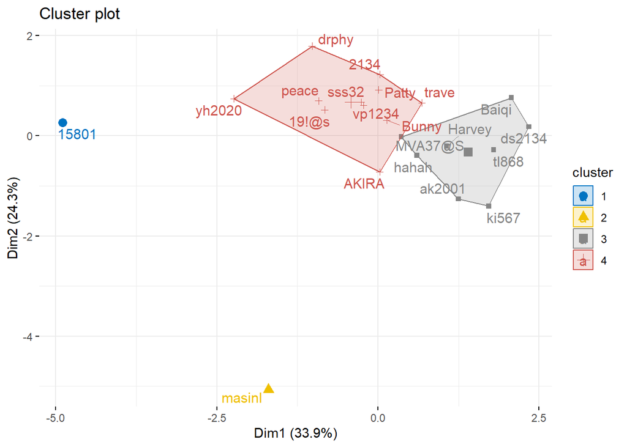

```r
km.res <- kmeans(matstd_socialmedia, 4, nstart = 25)
# Visualize
fviz_cluster(km.res, data = matstd_socialmedia,
             ellipse.type = "convex",
             palette = "jco",
             ggtheme = theme_minimal(),
             repel = TRUE)
```

**Inference:**

#### **Factor Analysis - To see the applications that can be grouped together**

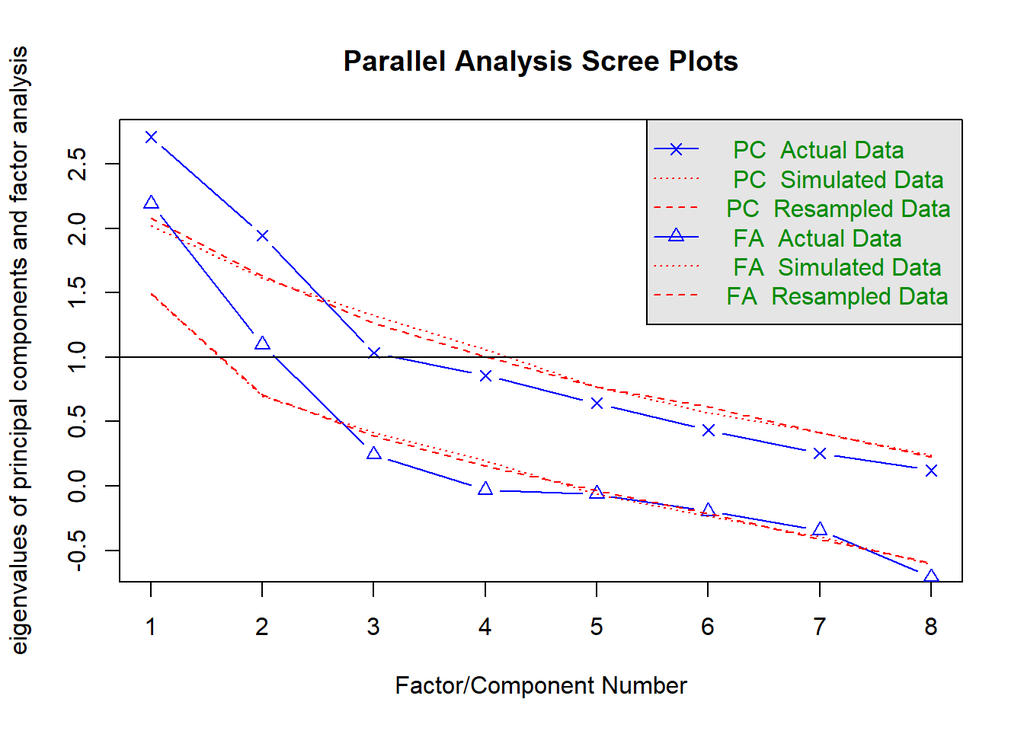

```
## Parallel analysis suggests that the number of factors =  2  and the number of components =  2
```

```r
fa.parallel(social_media_num)
```

**Inference**:

- Following the FA Actual Data, we can interpret as **2 to be the ideal number of factors**.

##### Factor Model

```r
fit.pc <- principal(social_media_num, nfactors=2, rotate="varimax")

round(fit.pc$values, 3)
```

```
## [1] 2.710 1.945 1.035 0.858 0.642 0.433 0.254 0.122
```

```r
fit.pc$loadings
```

```
##
## Loadings:
##                       RC1    RC2
## Instagram_Hours        0.741  0.457
## LinkedIn_Hours         0.632
## Snapchat_Hours         0.816  0.125
## Twitter_Hours         -0.227  0.879
## Whatsapp_Wechat_hours  0.624 -0.438
## Reddit_hours                  0.399
## Youtube_hours          0.589 -0.202
## OTT_hours              0.515  0.767
##
##                  RC1   RC2
## SS loadings    2.671 1.984
## Proportion Var 0.334 0.248
## Cumulative Var 0.334 0.582
```

**Inference:**

- The loadings give the correlation, and leave out the values that may be way below a threshold making it unimportant.
- An inference of how heavily correlated *Snapchat_Hours*, *Instagram_Hours* are to *RC1* can be drawn.
- Similarly, *Twitter_Hours*, and *OTT_Hours* are to *RC2*.

```r
fit.pc$communality
```

```
##       Instagram_Hours        LinkedIn_Hours        Snapchat_Hours
##             0.7587068             0.4067641             0.6818762
##         Twitter_Hours Whatsapp_Wechat_hours          Reddit_hours
##             0.8250142             0.5813503             0.1612115
##         Youtube_hours             OTT_hours
##             0.3874757             0.8530005
```

**Inference:**

- The column with the lowest communality scores can be referenced to be the least contributing.
- In this case, it can be observed that *Reddit_Hours* has the least communality score making it the least contributing column.

##### Visualizing the Columns that go into each Factor

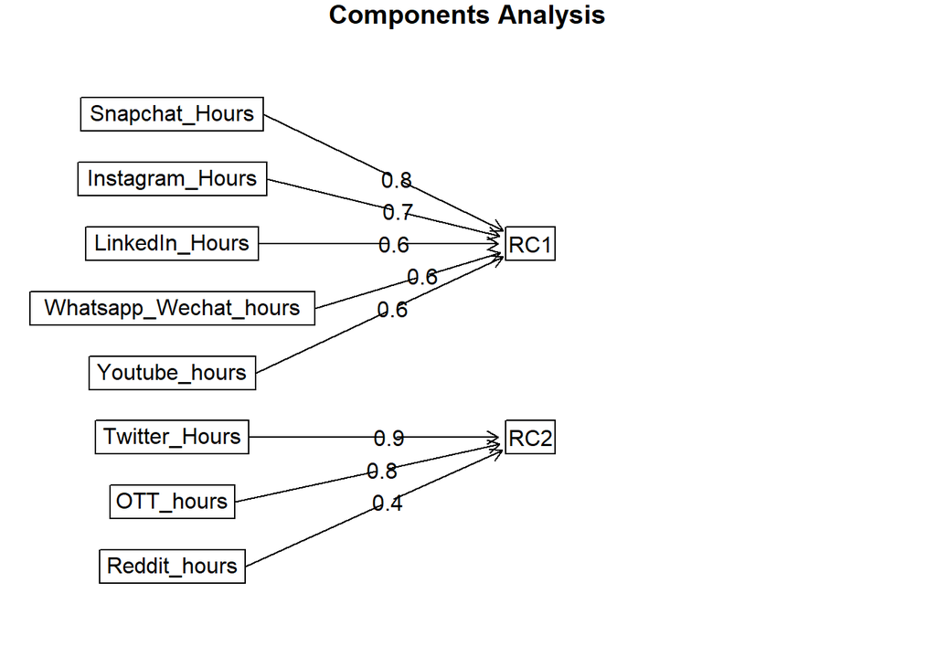

```r
fa.diagram(fit.pc)
```

**Inference:**

- The diagram is clearly representing how *Snapchat_Hours*, *Instagram_Hours* are heavily contributing to *RC1* whereas *LinkedIn_Hours*, *Whatsapp_Wechat_hours*, *Youtube_hours* contribute equally. This is indicative of how these applications are viewed more or less in similar patterns, making them more popular among students.
- *Twitter_Hours*, *OTT_Hours* are bigger contributors to *RC2*, whereas *Reddit_hours* contribute least. This showcases that Reddit is the least popular application, and Twitter, OTT are popular among a few students.

#### **In order to understand where I stand w.r.t to the other students, Z-scores can be calculated**

```r
means <- colMeans(social_media_num)
std_devs <- apply(social_media_num, 2, sd)

z_scores <- scale(social_media_num, center = means, scale = std_devs)

z_scores[18,]
```

```
##       Instagram_Hours        LinkedIn_Hours        Snapchat_Hours
##            0.19179943           -0.68112674            0.31592211
##         Twitter_Hours Whatsapp_Wechat_hours          Reddit_hours
##           -0.44978498            0.09836697           -0.33347426
##         Youtube_hours             OTT_hours
##           -1.27756549            0.02379202
```

**Inferences:**

- The Z-scores can help me identify how my **Youtube**, **LinkedIn**, and **Twitter** usage are **way below** my fellow classmates.
- Whereas **Instagram** is **slightly higher** than the average among my classmates.

### **Finding the best model to predict trouble sleeping**

#### **Multiple Regression**

```r
fit <- lm(Trouble_Sleeping_num~Instagram_Hours+LinkedIn_Hours+Snapchat_Hours+Twitter_Hours+Whatsapp_Wechat_hours+Reddit_hours+Youtube_hours+OTT_hours, data=social_media)

summary(fit)
```

```
##
## Call:
## lm(formula = Trouble_Sleeping_num ~ Instagram_Hours + LinkedIn_Hours +
##     Snapchat_Hours + Twitter_Hours + Whatsapp_Wechat_hours +
##     Reddit_hours + Youtube_hours + OTT_hours, data = social_media)
##
## Residuals:
##      Min       1Q   Median       3Q      Max
## -0.60834 -0.24317 -0.05131  0.20427  0.66610
##
## Coefficients:
##                       Estimate Std. Error t value Pr(>|t|)
## (Intercept)            0.49305    0.38624   1.277    0.226
## Instagram_Hours        0.01744    0.04981   0.350    0.732
## LinkedIn_Hours        -0.07144    0.05424  -1.317    0.212
## Snapchat_Hours         0.15215    0.10242   1.486    0.163
## Twitter_Hours         -0.01944    0.17061  -0.114    0.911
## Whatsapp_Wechat_hours -0.03855    0.03918  -0.984    0.345
## Reddit_hours          -0.03560    0.07633  -0.466    0.649
## Youtube_hours          0.05029    0.07772   0.647    0.530
## OTT_hours             -0.02886    0.06448  -0.448    0.662
##
## Residual standard error: 0.508 on 12 degrees of freedom
## Multiple R-squared:  0.3363, Adjusted R-squared:  -0.1061
## F-statistic: 0.7602 on 8 and 12 DF,  p-value: 0.6429
```

**Inferences:**

- None of the predictor variables (Instagram_Hours, LinkedIn_Hours, etc.) show a statistically significant relationship with the Trouble_Sleeping_num variable, as indicated by their high p-values.
- The model’s adjusted R-squared value of -0.1061 suggests that the model does not explain much of the variance in the Trouble_Sleeping_num variable.
- None of the social media usage variables significantly predict trouble sleeping, and the overall model is not statistically significant in explaining the variance in trouble sleeping behavior.

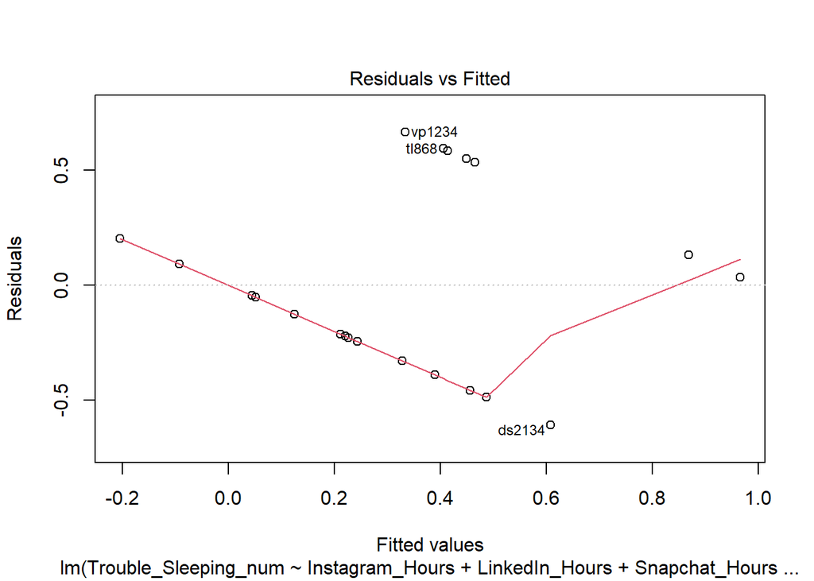

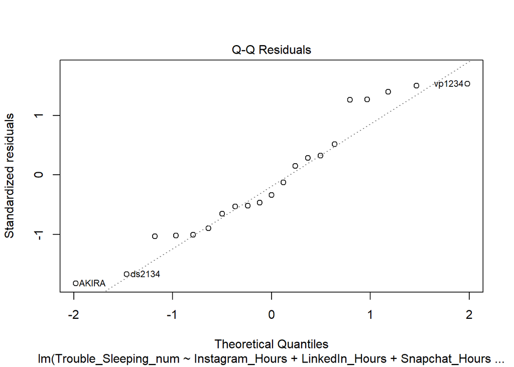

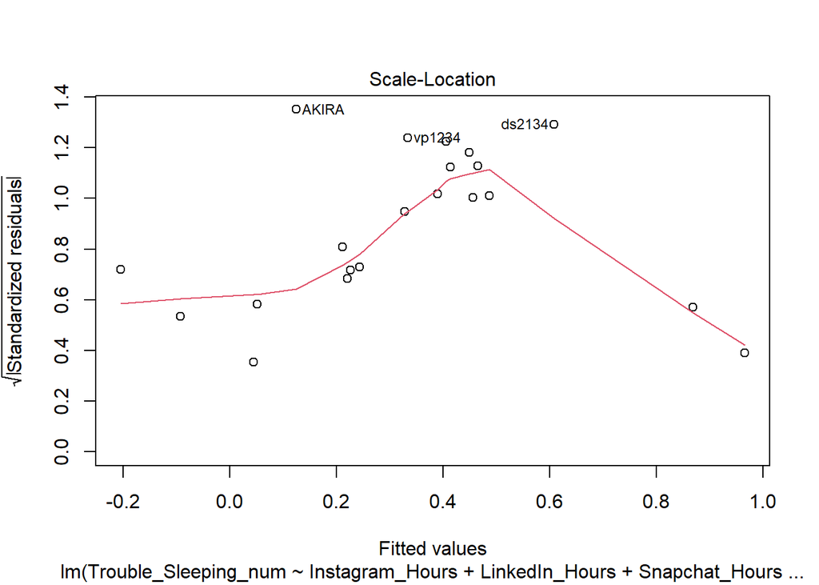

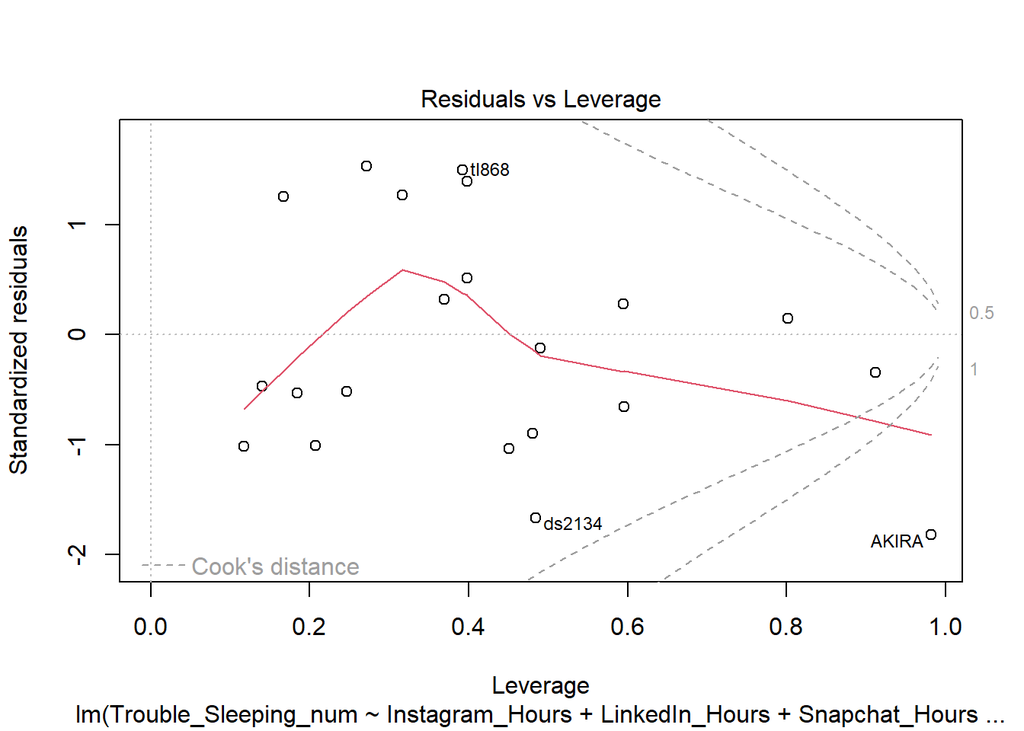

```r
plot(fit)
```

**Inferences:**

- The plots above are heavily relied upon to verify whether the model’s assumptions have been met. They help in identifying significant model issues.
- **1. Residuals Vs Fitted Values Plot:** This plot aims to highlight whether the residuals have constant variance between them. The expected manner would be to be scattered around the horizontal line. However, in our case they seem to be concentrated in a particular manner. Since we can observe a pattern in the diagram, it indicates heteroscedasticity or non-linearity in the model.
- **2. Q-Q Plot:** This plot compares the distribution of the residuals to the normal distribution. Since the points fall along the diagonal they indicate a normal distribution in the residuals.
- **3. Scale-Location Plot:** This plot helps to assess whether the variance of the residuals is constant (homoscedasticity). The spread of the points changing systematically with the fitted values indicates heteroscedasticity.
- **4. Residuals vs. Leverage Plot:** Points having high leverage and large residuals may be highly influential. This plot helps us determines whether these points should be considered.

**Since the Multiple Regression model was unable to give a good output, we can try Logistic Regression**

#### **Logistic Regression**

```r
logistic_reg <- glm(Trouble_Sleeping ~Instagram_Hours+LinkedIn_Hours+Snapchat_Hours+Twitter_Hours+Whatsapp_Wechat_hours+Reddit_hours+Youtube_hours+OTT_hours, data=social_media, family="binomial")

summary(logistic_reg)
```

```
##
## Call:
## glm(formula = Trouble_Sleeping ~ Instagram_Hours + LinkedIn_Hours +
##     Snapchat_Hours + Twitter_Hours + Whatsapp_Wechat_hours +
##     Reddit_hours + Youtube_hours + OTT_hours, family = "binomial",
##     data = social_media)
##
## Coefficients:
##                       Estimate Std. Error z value Pr(>|z|)
## (Intercept)           -0.49668    2.15669  -0.230    0.818
## Instagram_Hours        0.30097    0.34407   0.875    0.382
## LinkedIn_Hours        -0.69902    0.52211  -1.339    0.181
## Snapchat_Hours         1.26462    0.98630   1.282    0.200
## Twitter_Hours         -0.03163    0.77375  -0.041    0.967
## Whatsapp_Wechat_hours -0.33578    0.27323  -1.229    0.219
## Reddit_hours          -0.11034    0.44628  -0.247    0.805
## Youtube_hours          0.53381    0.66481   0.803    0.422
## OTT_hours             -0.33704    0.41879  -0.805    0.421
##
## (Dispersion parameter for binomial family taken to be 1)
##
##     Null deviance: 26.734  on 20  degrees of freedom
## Residual deviance: 17.665  on 12  degrees of freedom
## AIC: 35.665
##
## Number of Fisher Scoring iterations: 6
```

**Inferences:**

- None of the predictor variables (Instagram_Hours, LinkedIn_Hours, etc.) show a statistically significant relationship with the Trouble_Sleeping variable, as indicated by their high p-values.
- The model’s residual deviance of 17.665 on 12 degrees of freedom suggests a decent fit to the data, although there may still be unexplained variability.
- Similar to the previous model, there is no evidence to support a significant relationship between social media usage variables and trouble sleeping behavior.

##### Predicted Data

```r
predicted.data <- data.frame(probability.of.sleep=logistic_reg$fitted.values,Sleep=social_media$Trouble_Sleeping)
predicted.data <- predicted.data[order(predicted.data$probability.of.sleep, decreasing=FALSE),]
predicted.data$rank <- 1:nrow(predicted.data)

predicted.data
```

```
##         probability.of.sleep        Sleep rank
## Patty            0.001396880 Not Troubled    1
## drphy            0.004505334 Not Troubled    2
## Baiqi            0.012281963 Not Troubled    3
## masinl           0.060724163 Not Troubled    4
## Bunny            0.088001046 Not Troubled    5
## trave            0.110094884 Not Troubled    6
## AKIRA            0.135802035 Not Troubled    7
## 2134             0.144754207 Not Troubled    8
## sss32            0.205107739 Not Troubled    9
## ak2001           0.245677726 Not Troubled   10
## yh2020           0.272724996 Not Troubled   11
## tl868            0.300116024     Troubled   12
## vp1234           0.319541875     Troubled   13
## 19!@s            0.333288089     Troubled   14
## MVA37@S          0.440705366 Not Troubled   15
## ki567            0.511371815     Troubled   16
## Harvey           0.554917030     Troubled   17
## hahah            0.597134602 Not Troubled   18
## ds2134           0.694261625 Not Troubled   19
## peace            0.976198024     Troubled   20
## 15801            0.991394569     Troubled   21
```

**Inference:**

- The dataframe comprises of the probabilities of status, as well as the corresponding STATUS in our data.

##### Plotting of predicted probabilities

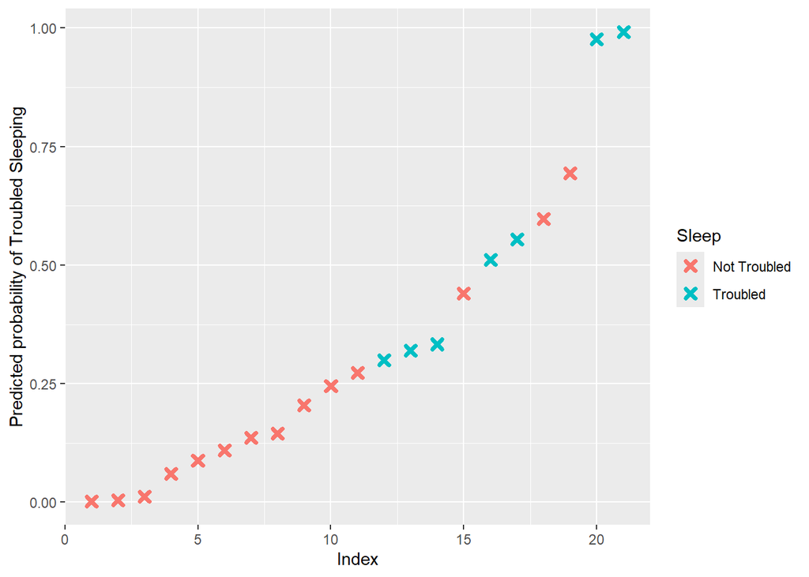

```r
ggplot(data=predicted.data, aes(x=rank, y=probability.of.sleep)) +
geom_point(aes(color=Sleep), alpha=1, shape=4, stroke=2) +
xlab("Index") +
ylab("Predicted probability of Troubled Sleeping")
```

**Inferences:**

- There is not much clear distinction between the two classes indicating that the model may not be as great.

```r
pdata <- predict(logistic_reg,newdata=social_media,type="response" )
pdataF <- as.factor(ifelse(test=as.numeric(pdata>0.5) == 0, yes="Troubled", no="Not Troubled"))

confusionMatrix(pdataF, social_media$Trouble_Sleeping)
```

```
## Confusion Matrix and Statistics
##
##               Reference
## Prediction     Not Troubled Troubled
##   Not Troubled            2        4
##   Troubled               12        3
##
##                Accuracy : 0.2381
##                  95% CI : (0.0822, 0.4717)
##     No Information Rate : 0.6667
##     P-Value [Acc > NIR] : 0.99999
##
##                   Kappa : -0.3333
##
##  Mcnemar's Test P-Value : 0.08012
##
##             Sensitivity : 0.14286
##             Specificity : 0.42857
##          Pos Pred Value : 0.33333
##          Neg Pred Value : 0.20000
##              Prevalence : 0.66667
##          Detection Rate : 0.09524
##    Detection Prevalence : 0.28571
##       Balanced Accuracy : 0.28571
##
##        'Positive' Class : Not Troubled
##
```

**Inferences:**

- The model performs poorly with an accuracy of 23.81%.
- The 95% confidence interval is between 0.0822 and 0.4717 for our logistic regression model.
- Sensitivity (true positive rates), and Specificity (true negative rates) are 0.14 and 0.428 respectively.
- Balanced Accuracy provides a balanced measure of model performance by taking into account the imbalance in class distribution, which is calculated by taking the average of Sensitivity and Specificity which 0.286.

#### **Linear Discriminant Analysis**

##### Splitting the data into Train and Test

```r
social_media_df <- social_media[, c("Instagram_Hours",  "LinkedIn_Hours",   "Snapchat_Hours", "Twitter_Hours",  "Whatsapp_Wechat_hours", "Reddit_hours",    "Youtube_hours",    "OTT_hours", "Trouble_Sleeping")]
```

```r
set.seed(42) #Keeping the train/test split consistent in all runs

smp_size_raw <- floor(0.75 * nrow(social_media_df))

train_ind_raw <- sample(nrow(social_media_df), size = smp_size_raw)

#Creating Train and Test Data
train_raw.df <- as.data.frame(social_media_df[train_ind_raw, ])
test_raw.df <- as.data.frame(social_media_df[-train_ind_raw, ])
```

##### Creating the model

```r
sm_lda <- lda(formula = train_raw.df$Trouble_Sleeping ~ ., data = train_raw.df)
sm_lda
```

```
## Call:
## lda(train_raw.df$Trouble_Sleeping ~ ., data = train_raw.df)
##
## Prior probabilities of groups:
## Not Troubled     Troubled
##    0.6666667    0.3333333
##
## Group means:
##              Instagram_Hours LinkedIn_Hours Snapchat_Hours Twitter_Hours
## Not Troubled           5.600          3.748          0.847         0.527
## Troubled               6.864          3.172          2.884         0.618
##              Whatsapp_Wechat_hours Reddit_hours Youtube_hours OTT_hours
## Not Troubled                 7.147         0.25         3.098     2.664
## Troubled                     6.706         0.20         3.182     3.000
##
## Coefficients of linear discriminants:
##                              LD1
## Instagram_Hours       -0.2708934
## LinkedIn_Hours        -0.3893767
## Snapchat_Hours         1.9876064
## Twitter_Hours          1.9938117
## Whatsapp_Wechat_hours  0.2163040
## Reddit_hours           2.3767141
## Youtube_hours          0.3759605
## OTT_hours             -0.9303420
```

**Inferences:**

- The prior probability of being Troubled is 0.33, indicating that approximately one-third of the observations in the training dataset are labeled as Troubled.
- The means of the predictor variables for each group (Not Troubled and Troubled) show differences between the two groups. For example, Troubled individuals tend to have higher mean values for “Snapchat_Hours”, “Instagram_Hours”, “Twitter_Hours”, “YouTube_Hours”, and “OTT_Hours” compared to Not Troubled individuals.
- The coefficients of the linear discriminants (LD1) indicate the contribution of each predictor variable to the separation between the two groups. Positive coefficients indicate that higher values of the predictor variable are associated with the Troubled group, while negative coefficients indicate the opposite.
- For example, higher values of Snapchat_Hours, Twitter_Hours, Reddit_hours, Whatsapp_Wechat_hours and Youtube_hours contribute to classifying an individual as Troubled, while higher values of Instagram_Hours, LinkedIn_Hours, and OTT_hours contribute to classifying an individual as Not Troubled.

**Since the model seems to be giving better results, let’s further evaluate the model’s performance**

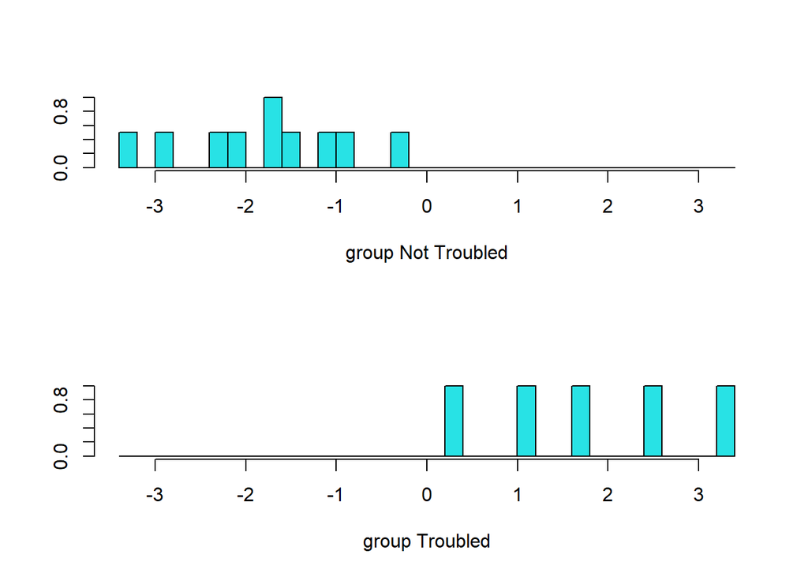

```r
plot(sm_lda)
```

**Inference:**

- Lack of much overlap is an indication of a good model

#### Prediction

```r
sm.lda.predict <- predict(sm_lda, newdata = test_raw.df)
sm.lda.predict$class
```

```
## [1] Not Troubled Troubled     Not Troubled Not Troubled Troubled
## [6] Not Troubled
## Levels: Not Troubled Troubled
```

```r
sm.lda.predict$x
```

```
##                LD1
## Patty  -3.52222209
## ak2001  3.08026990
## Harvey -2.34997329
## hahah   0.05799171
## AKIRA  15.75550243
## vp1234 -1.57886495
```

**Inferences:**

#### Model Accuracy

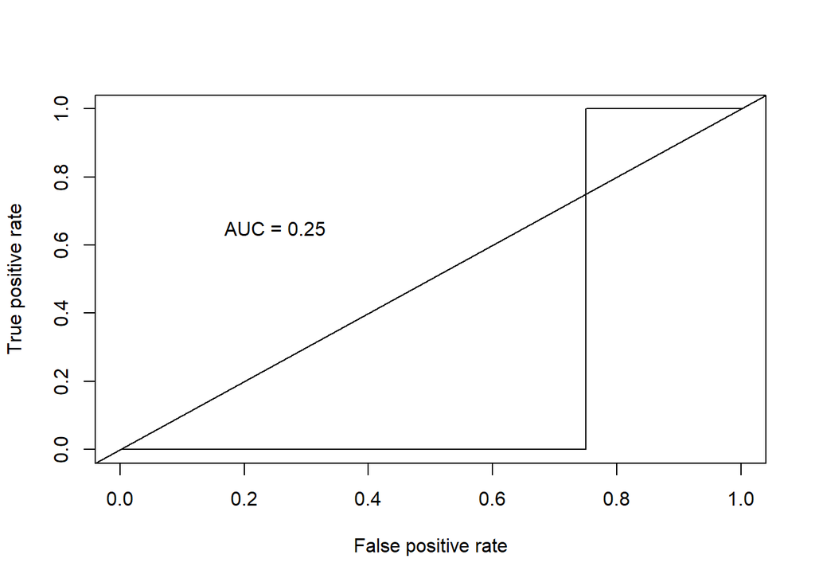

```
## integer(0)
```

```r
# Get the posteriors as a dataframe.
sm.lda.predict.posteriors <- as.data.frame(sm.lda.predict$posterior)

pred <- prediction(sm.lda.predict.posteriors[,2], test_raw.df$Trouble_Sleeping)
roc.perf = performance(pred, measure = "tpr", x.measure = "fpr")
auc.train <- performance(pred, measure = "auc")
auc.train <- auc.train@y.values

plot(roc.perf)+abline(a=0, b= 1)+text(x = .25, y = .65 ,paste("AUC = ", round(auc.train[[1]],3), sep = ""))
```

```r
# Predict class labels for the test dataset
predicted_labels <- predict(sm_lda, newdata = test_raw.df)$class

# Calculate accuracy
actual_labels <- test_raw.df$Trouble_Sleeping
accuracy <- mean(predicted_labels == actual_labels)

cat("Accuracy:", accuracy, "\n")
```

```
## Accuracy: 0.3333333
```

**Inferences:**

- Based on the AUC and accuracy (0.25 and 0.33 respectively), we can infer that the model has a poor performance in predicting whether the students have trouble falling asleep or not.
- While the model may not be adept at differentiating groups, it can be attributed to the imbalanced data that we have. (67% - Not Troubled; 33% - Troubled)